# Tree Based Methods Workshop

Anamaria Elek

2022-09-19

In this workshop we are going to use tree-based methods to construct Gene Regulatory Networks (GRNs).

## Introduction

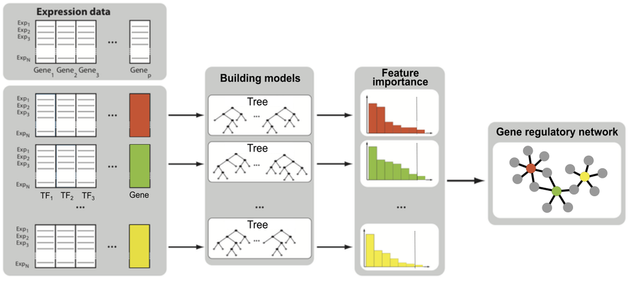

The expression of each gene is regulated by a set of transcription factors (TFs). If a level of TF expression is changed (e.g. a TF is knocked-down), the expression level of it’s downstream target genes will be affected. We can therefore build a model that predicts expression of a particular gene based on the expression of it’s (potential) regulator TFs. The TFs with higher importance in the model are more likely to be true regulators of that particular gene. By building such models for the group of genes we are interested in, and linking genes to TFs, we can obtain simple co-expression based Gene Regulatory Networks (GRNs).

Tree based methods are particularly suitable for this problem because:

- they make essentially no assumptions about the nature of the relationships between TF and gene expression (which can be non-linear),
- they can potentially capture high-order conditional dependencies between expression patterns,
- they can handle having many features,
- their interpretability allows direct selection of important TFs.

## Setup

```r
library(data.table)
library(stringr)
library(ggplot2)
library(caret)
library(rpart)
library(rpart.plot)
library(ipred)
library(ranger)
library(party)
library(bst)

theme_set(theme_linedraw())
```

## Data

GTEx portal contains gene expression data for various human tissues, you can access the data [here](https://www.gtexportal.org/home/datasets#filesetFilesDiv131).

We will use transcript-per-million (TPM) normalized gene counts. This normalization accounts for different sequencing depths in different samples (i.e. features are on the same scale and comparable between samples). TPM is, however, biased by gene length (i.e. longer gene is going to have more TPMs than a shorter gene expressed at the same level).

Is this a problem and how should we deal with it?

We will work with 578 lung samples. You can download the data directly from GTEx or load the local copy.

```r
# download data from GTEx portal
url <- "https://storage.googleapis.com/gtex_analysis_v8/rna_seq_data/gene_reads/gene_reads_2017-06-05_v8_lung.gct.gz"
dt <- fread(url)
```

```r
# load local copy of data
dt <- fread("data/gene_tpm_2017-06-05_v8_lung.gct.gz")
```

```r
dim(dt)
```

```
## [1] 56200   581
```

```r
dt[1:10,1:10]
```

| id | Name | Description | GTEX-111CU-0326-SM-5GZXO | GTEX-111FC-1126-SM-5GZWU | GTEX-111VG-0726-SM-5GIDC | GTEX-111YS-0626-SM-5GZXV | GTEX-1122O-0126-SM-5GICA | GTEX-1128S-0726-SM-5N9D6 | GTEX-117YW-0526-SM-5H11C |
| --- | --- | --- | --- | --- | --- | --- | --- | --- | --- |
| 0 | ENSG00000223972.5 | DDX11L1 | 0.0000 | 0.0000 | 0.0512 | 0.0000 | 0.0000 | 0.0312 | 0.0000 |
| 1 | ENSG00000227232.5 | WASH7P | 1.7940 | 6.9100 | 4.3020 | 1.8240 | 2.2360 | 4.2270 | 7.7380 |
| 2 | ENSG00000278267.1 | MIR6859-1 | 0.0000 | 0.0000 | 0.0000 | 0.0000 | 0.0000 | 0.0000 | 0.0000 |
| 3 | ENSG00000243485.5 | MIR1302-2HG | 0.0000 | 0.0000 | 0.0000 | 0.0000 | 0.0000 | 0.0000 | 0.0645 |
| 4 | ENSG00000237613.2 | FAM138A | 0.0000 | 0.0000 | 0.0363 | 0.0000 | 0.0000 | 0.0443 | 0.0000 |
| 5 | ENSG00000268020.3 | OR4G4P | 0.0000 | 0.0700 | 0.0000 | 0.0555 | 0.0000 | 0.0000 | 0.0665 |
| 6 | ENSG00000240361.1 | OR4G11P | 0.0430 | 0.0626 | 0.1884 | 0.0000 | 0.0000 | 0.0000 | 0.0000 |
| 7 | ENSG00000186092.4 | OR4F5 | 0.0440 | 0.0641 | 0.0965 | 0.0508 | 0.0000 | 0.0000 | 0.0000 |
| 8 | ENSG00000238009.6 | RP11-34P13.7 | 0.0393 | 0.1144 | 0.0000 | 0.1586 | 0.0437 | 0.0787 | 0.0000 |
| 9 | ENSG00000233750.3 | CICP27 | 0.3966 | 0.1019 | 0.0128 | 0.2692 | 0.4418 | 0.2806 | 0.0323 |

There are 56,200 genes from 578 lung samples in our data.

Since we will only use TFs as variables in our model, we will include additional column to specify if the gene is a TF or not. You can download a list of 1639 human TFs from the curated database [here](http://humantfs.ccbr.utoronto.ca/download.php), or again, load a local copy of this data.

```r
# download TF data
url <- "http://humantfs.ccbr.utoronto.ca/download/v_1.01/TFs_Ensembl_v_1.01.txt"
tfs <- readLines(url)
```

```r
# load local copy of TF data
tfs <- readLines("data/TFs_Ensembl_v_1.01.txt")
head(tfs)
```

```
## [1] "DUX1_HUMAN"      "DUX3_HUMAN"      "ENSG00000001167" "ENSG00000004848"
## [5] "ENSG00000005073" "ENSG00000005102"
```

```r
length(tfs)
```

```
## [1] 1639
```

```r
# strip transcript ID from GTEx data
dt[, Name := str_remove(Name, "\\.\\d+$")]

# add TF info
dt[,TF := ifelse(Name %in% tfs, TRUE, FALSE)]
setcolorder(dt, c("id","Name","Description","TF"))

# we will use more informative gene names instead of ensembl IDs
dt[,Description:=str_replace(Description,"-","_")] # - causes formula to break
tfs <- dt[TF == TRUE, Description]
```

Let’s do some exploratory data analysis.

```r
# extract only TPM values
tpm <- dt[,-c(1:4)]
# transpose to have observations in rows and features in columns
tpm <- as.data.frame(t(tpm))
colnames(tpm) <- dt$Description
quants <- t(apply(tpm, 1, quantile))
head(quants)
```

```
##                          0% 25%    50%     75%  100%
## GTEX-111CU-0326-SM-5GZXO  0   0 0.0546 2.17700 29950
## GTEX-111FC-1126-SM-5GZWU  0   0 0.1284 3.97450 19550
## GTEX-111VG-0726-SM-5GIDC  0   0 0.1449 3.94725 16000
## GTEX-111YS-0626-SM-5GZXV  0   0 0.0662 2.82025 24130
## GTEX-1122O-0126-SM-5GICA  0   0 0.0617 2.87775 31970
## GTEX-1128S-0726-SM-5N9D6  0   0 0.0976 3.46775 28380
```

We can remove genes that are not expressed in any sample.

```r
# remove genes not expressed in any sample
not_expressed <- which(colSums(tpm) == 0)
length(not_expressed)
```

```
## [1] 2127
```

```r
tpm <- tpm[, -not_expressed]
quants <- t(apply(tpm, 1, quantile))
head(quants)
```

```
##                          0% 25%    50%   75%  100%
## GTEX-111CU-0326-SM-5GZXO  0   0 0.0797 2.559 29950
## GTEX-111FC-1126-SM-5GZWU  0   0 0.1691 4.602 19550
## GTEX-111VG-0726-SM-5GIDC  0   0 0.1853 4.483 16000
## GTEX-111YS-0626-SM-5GZXV  0   0 0.0951 3.300 24130
## GTEX-1122O-0126-SM-5GICA  0   0 0.0905 3.387 31970
## GTEX-1128S-0726-SM-5N9D6  0   0 0.1304 4.024 28380
```

Next we log transform the data and remove genes that are very lowly expressed in most of the samples. Log transformations will spread out smaller values and bring down very large ones, primarily making it easier to look ato the data.

```r
# log transform
tpm <- log(tpm+1)
quants <- t(apply(tpm, 1, quantile))
head(quants)
```

```
##                          0% 25%        50%      75%      100%
## GTEX-111CU-0326-SM-5GZXO  0   0 0.07668322 1.269480 10.307318
## GTEX-111FC-1126-SM-5GZWU  0   0 0.15623422 1.723124  9.880782
## GTEX-111VG-0726-SM-5GIDC  0   0 0.16999591 1.701652  9.680406
## GTEX-111YS-0626-SM-5GZXV  0   0 0.09084568 1.458615 10.091253
## GTEX-1122O-0126-SM-5GICA  0   0 0.08663631 1.478646 10.372585
## GTEX-1128S-0726-SM-5N9D6  0   0 0.12257155 1.614226 10.253475
```

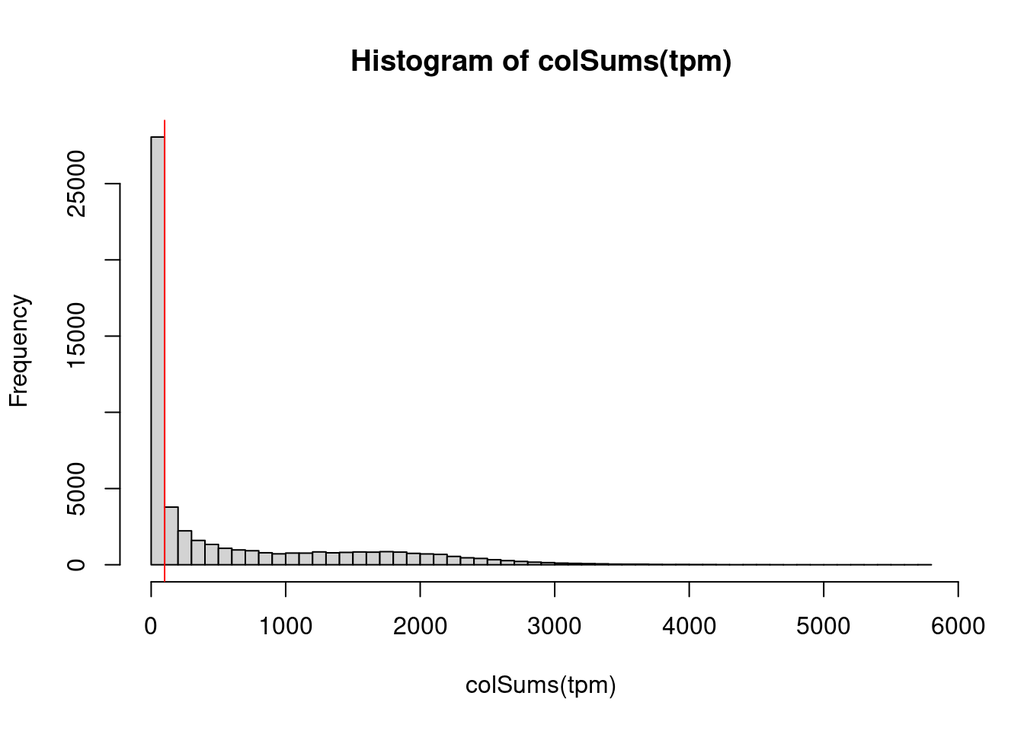

```r
# remove lowly expressed genes
hist(colSums(tpm), breaks = 50); abline(v=100, col="red")
```

```r
low_expressed <- which(colSums(tpm) < 100)
sum(names(low_expressed) %in% tfs)
```

```
## [1] 286
```

```r
tpm <- tpm[, -low_expressed]

# how many TFs (i.e. variables) we have left?
tfs <- tfs[tfs %in% colnames(tpm)]
length(tfs)
```

```
## [1] 1344
```

**Note**: A more sophisticated feature selection methods are available, they will be covered in tomorrow’s lectures.

Split the data into train and test samples.

```r
set.seed(1950)
tpm_train_id <- sample(1:nrow(tpm), size = 0.9 * nrow(tpm))
tpm_train <- tpm[tpm_train_id, ]; nrow(tpm_train)
```

```
## [1] 520
```

```r
tpm_test  <- tpm[-tpm_train_id, ]; nrow(tpm_test)
```

```
## [1] 58
```

First we will fit different regression trees to predict individual genes expression. We will build models for **SFTPA1**, a member of SFTP gene family encoding lung surfactant proteins. Same approach can then be applied to all other genes.

Same approach can then be applied to all other genes.

```r
# outcome variable
gene <- "SFTPA1"

# predictor variables
tfs <- setdiff(tfs, gene)
```

## Regression Tree

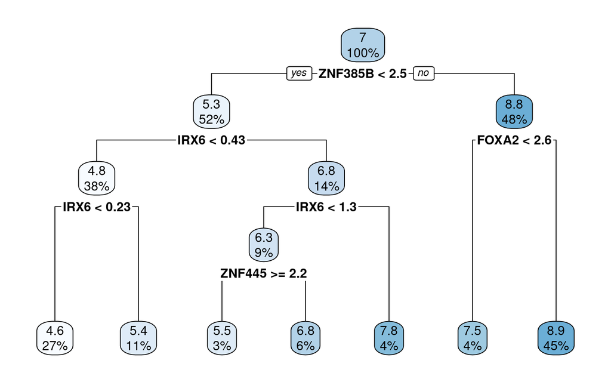

```r
require(rpart)

set.seed(1950)

# build tree
tpm_tree <- rpart(
  formula = as.formula(paste(gene, "~ .", collapse = " ")),
  data = tpm_train[,c(gene,tfs)],
  method = "anova" # for regression
)

# plot tree
require(rpart.plot)
rpart.plot(tpm_tree)
```

The tree is showing the percentage of data that fall to each node, and the average log transformed TPM for corresponding branch.

**QUESTION:** Why is it important to set hyperparameters for tree building?

Setting parameters for building a decision tree is very important because decision trees are non-parametric models - meaning not that they have no parameters, but rather, that the number of parameters is not defined before fitting the model (unlike, for example in regression). If we don’t define any hyperparameters that would restrict the whole process, in theory, a very complex decision tree could be build that very closely matches the training data, and obviously is overfitting.

`rpart` implementation of tree bullding algorithm automatically performs a cross validation for a range of cost complexity values `cp` used to prune the tree. Pruning means that any split that does not improve the performance by a factor of `cp` is not attempted - this both saves computational time and prevents overfitting.

We can look at the reduction in cross-validation error with increased number of splits.

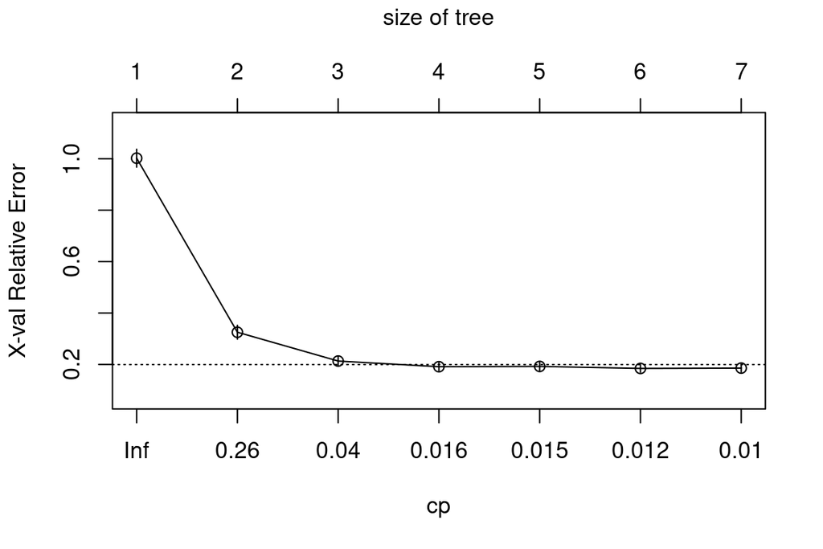

```r
plotcp(tpm_tree)
```

Note that this CV error is equivalent to predicted residual error sum of squares (PRESS); it is not equivalent to the root mean squared error (RMSE) which we will calculate later.

```r
# get stats for different cp values
tpm_tree$cptable
```

```
##           CP nsplit rel error    xerror       xstd
## 1 0.72873415      0 1.0000000 1.0022164 0.03487766
## 2 0.09568011      1 0.2712659 0.3252300 0.02678797
## 3 0.01649306      2 0.1755857 0.2131730 0.01963205
## 4 0.01597320      3 0.1590927 0.1911472 0.01559536
## 5 0.01444900      4 0.1431195 0.1923030 0.01602811
## 6 0.01012827      5 0.1286705 0.1844618 0.01510479
## 7 0.01000000      6 0.1185422 0.1857420 0.01515793
```

In addition to the cost complexity `cp`, other `rpart` parameters we can tune are:

- `minsplit`, the minimum number of data points required to attempt a split before it is forced to create a terminal node (default is 20)
- `maxdepth`, the maximum number of internal nodes between the root node and the terminal nodes (default is 30).

In order to automatically tune the values of decision tree parameters, we create a search grid and iterate over it.

```r
hyper_grid <- expand.grid(
  minsplit = seq(20, 50, 2),
  maxdepth = seq(20, 50, 2)
)
# total combinations
nrow(hyper_grid)
```

```
## [1] 256
```

Note that this is many combinations to test for, and it will take a lot of time. For this reason, don’t run the code below, we will load pre-calculated grid search results instead.

```r
# loop over grid search
set.seed(1950)
tpm_list <- lapply(1:nrow(hyper_grid), function(i) {

  # train a model
  tpm_tree <- rpart(
    formula = as.formula(paste(gene, "~ .", collapse = " ")),
    data = tpm_train[, c(gene,tfs)],
    method  = "anova",
    control = list(
      minsplit = hyper_grid$minsplit[i],
      maxdepth = hyper_grid$maxdepth[i]
    )
  )

  # get error
  tpm_tree$cptable[which.min(tpm_tree$cptable[,"xerror"]),]

  })

# merge results
tpm_cp <- do.call('rbind', tpm_list)

# add results to grid
hyper_grid <- cbind(hyper_grid, tpm_cp)

# save
fwrite(hyper_grid, file = sprintf("data/hypergrid.tree.%s.csv",gene))
```

After building all the models, we select the parameters with lowest CV error.

```r
hyper_grid <- fread(sprintf("data/hypergrid.tree.%s.csv",gene))
head(hyper_grid[order(xerror)])
```

| minsplit | maxdepth | CP | nsplit | rel error | xerror | xstd |
| --- | --- | --- | --- | --- | --- | --- |
| 34 | 28 | 0.01000000 | 6 | 0.1185422 | 0.1669321 | 0.01453401 |
| 20 | 38 | 0.01012827 | 5 | 0.1286705 | 0.1687527 | 0.01451537 |
| 32 | 40 | 0.01012827 | 5 | 0.1286705 | 0.1697405 | 0.01497416 |
| 50 | 50 | 0.01000000 | 5 | 0.1286705 | 0.1705137 | 0.01508352 |
| 34 | 26 | 0.01000000 | 6 | 0.1185422 | 0.1706392 | 0.01561290 |
| 34 | 40 | 0.01000000 | 6 | 0.1185422 | 0.1709182 | 0.01486082 |

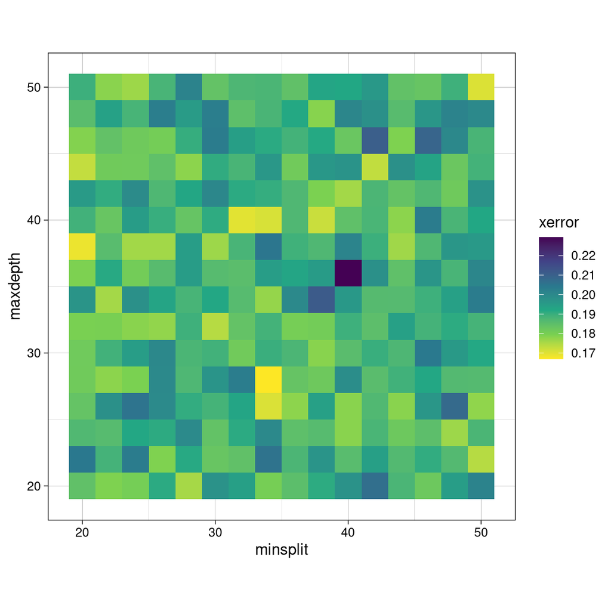

```r
# plot grid search results
ggplot(hyper_grid, aes(minsplit, maxdepth, fill = xerror)) +
  geom_tile() + coord_fixed() + scale_fill_viridis_c(direction = -1)
```

**QUESTION:** Compare the error for top model to that calculated for the first tree built with the default parameters.

**TASK:** Use the best parameters to build the final model.

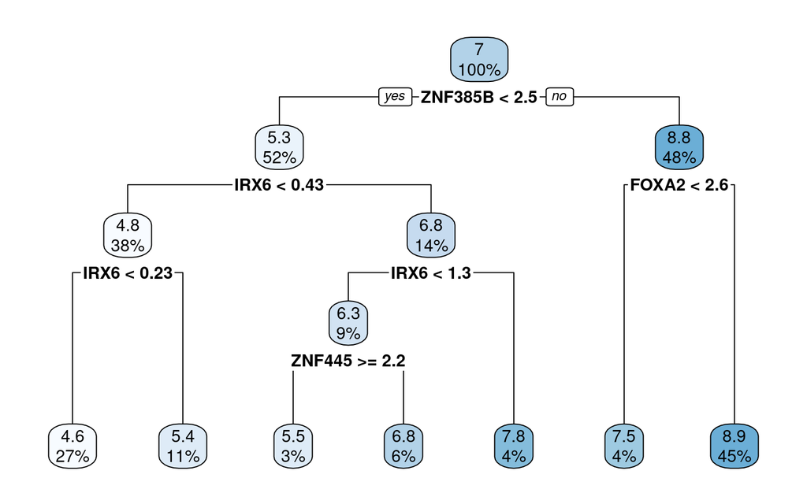

```r
# build the model using best parameters from grid search
i <- which.min(hyper_grid$xerror)
tpm_best_tree <- rpart(
  formula = as.formula(paste(gene, "~ .", collapse = " ")),
  data = tpm_train[, c(gene,tfs)],
  method  = "anova",
  control = list(
    minsplit = hyper_grid$minsplit[i],
    maxdepth = hyper_grid$maxdepth[i],
    cp = hyper_grid$CP[i]
  )
)

# plot tree
rpart.plot(tpm_tree)
```

Use this model for prediction with test data.

```r
pred <- predict(tpm_best_tree, newdata = tpm_test[, tfs])
RMSE(pred = pred, obs = tpm_test[, gene])
```

```
## [1] 0.9688146
```

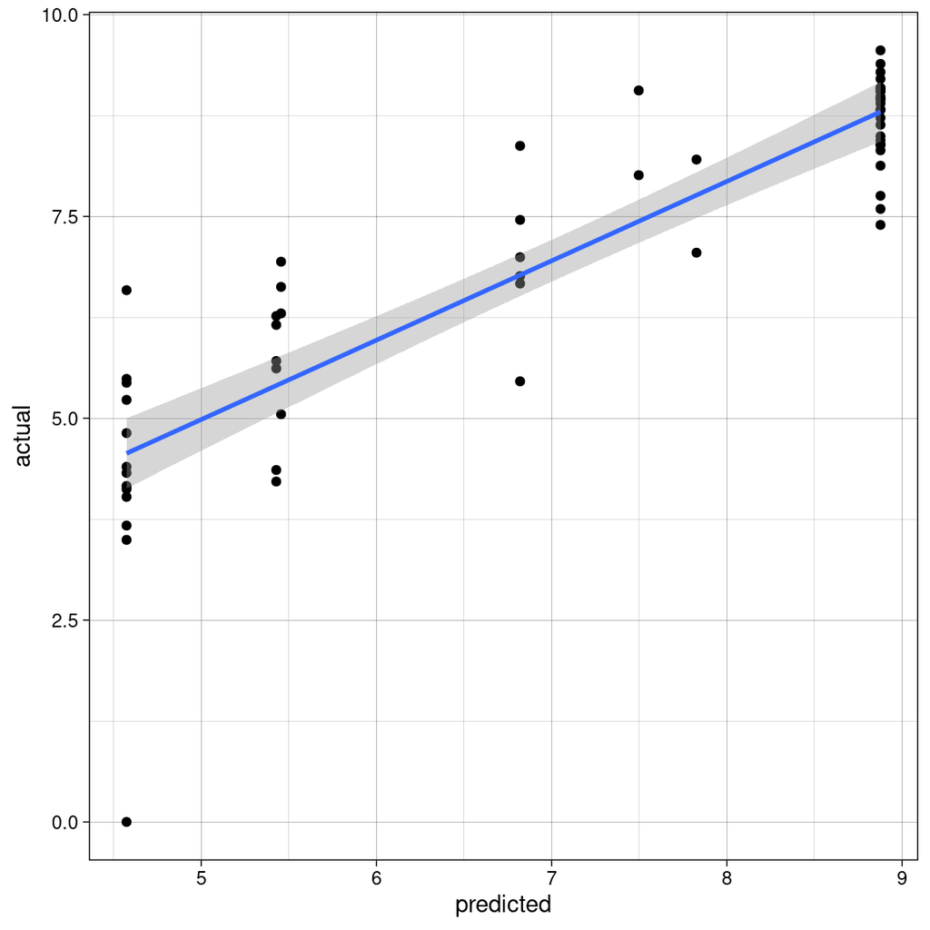

```r
pred_df <- data.frame(predicted=pred, actual=tpm_test[, gene])
ggplot(pred_df, aes(predicted, actual)) +
  geom_point() +
  geom_smooth(method='lm', formula=y~x)
```

## Bagging

First ensemble method we will try is Bagging. Main parameter for bagging is the number of trees to average (`nbagg`, default is 25). Increasing this value results in lower error, but after the initial drop, it soon becomes stable.

**QUESTION:** What will happen if we keep increasing number of trees used in bagging?

### `ipred`

We can train a regression tree with bagging similarly to training a single tree, using `ipred::bagging` function. We will build models with different number of averaged trees, and retrieve out-of-the-bag OOB error for each (`ipred` does not perform CV).

```r
require(ipred)

set.seed(1950)

# get OOB errors for models with range of bagged trees
nbagg <- seq(10, 200, 2)

rmse <- sapply(nbagg, function(i) {
  bt <- bagging(
    formula = as.formula(paste(gene, "~ .", collapse = " ")),
    data = tpm_train[,c(gene,tfs)],
    coob = TRUE,
    nbagg = i
  )
  bt$err
})

rmse_df <- data.frame(nbagg, rmse)
fwrite(rmse_df, file = sprintf("data/hypergrid.bagging.%s.csv",gene))
```

**TASK:** Build a model using best performing `nbagg` value. This will take a bit longer than building a single tree (e.g. it takes a few minutes on a PC with 8 cores and 14GB RAM).

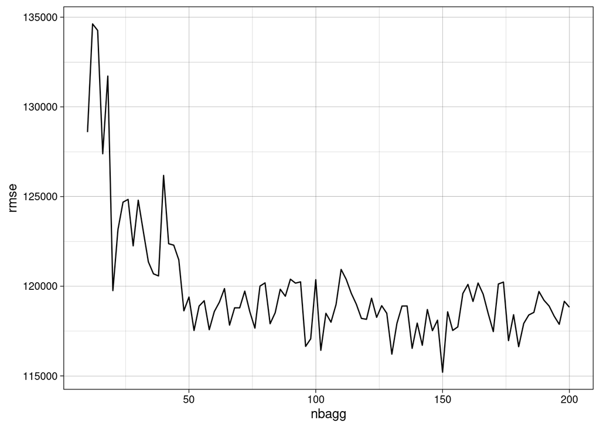

```r
# load precalculated values
rmse_df <- fread(sprintf("data/hypergrid.bagging.%s.csv",gene))
ggplot(rmse_df, aes(nbagg, rmse)) +
  geom_line()
```

```r
# fit model using these parameters
ntree <- rmse_df[which.min(rmse_df$rmse),]$nbagg
bagging_tree <- bagging(
  formula = as.formula(paste(gene, "~ .", collapse = " ")),
  data = tpm_train[,c(gene,tfs)],
  coob = TRUE,
  nbagg = ntree
)
```

**TASK:** Use bagging model for prediction with test data.

```r
# prediction
pred <- predict(bagging_tree, newdata = tpm_test[, tfs])
RMSE(pred = pred, obs = tpm_test[, gene])
```

```
## [1] 1.101242
```

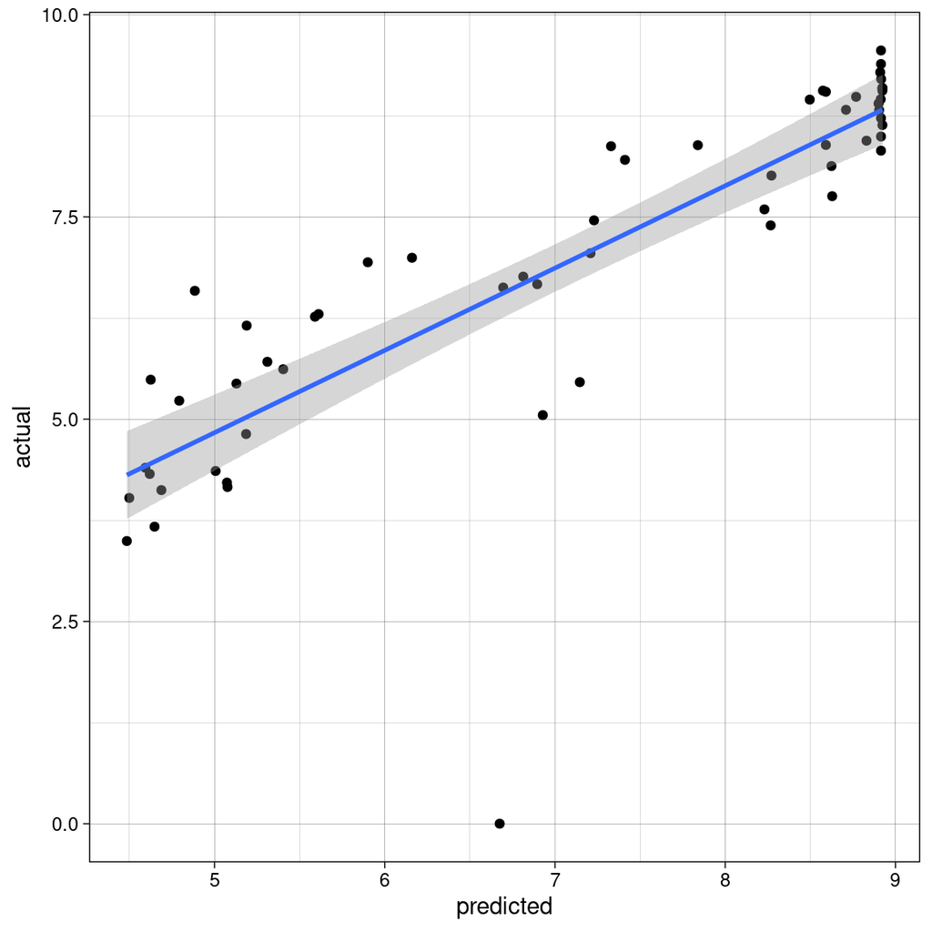

```r
pred_df <- data.frame(predicted=pred, actual=tpm_test[, gene])
ggplot(pred_df, aes(predicted, actual)) +
  geom_point() +
  geom_smooth(method='lm', formula=y~x)
```

### `caret`

Alternatively, we can use `caret::train()` function which can fit a variety of different models (238, to be precise, see info [here](https://topepo.github.io/caret/available-models.html)), including bagging trees (see `names(getModelInfo())`). It’s advantages are that it can automatically perform cross-validation and calculate variable importance.

```r
require(caret)

# set up a 10-fold cross validation
ctrl <- trainControl(method = "cv",  number = 10)

# CV bagged model
bagging_tree <- caret::train(
  x = tpm_train[,tfs],
  y = tpm_train[,gene],
  method = "treebag",
  num.trees = ntree,
  trControl = ctrl,
  importance = TRUE
)
```

Note that we could in theory use the same formula syntax as with `pred`, however, `ipred` has a problem with formula parsing of some of the column names, so we specify `x` and `y` values directly)

```r
# assess results
bagging_tree
```

```
## Bagged CART
##
##  520 samples
## 1344 predictors
##
## No pre-processing
## Resampling: Cross-Validated (10 fold)
## Summary of sample sizes: 468, 467, 468, 468, 468, 468, ...
## Resampling results:
##
##   RMSE       Rsquared   MAE
##   0.7023396  0.8809164  0.5281077
```

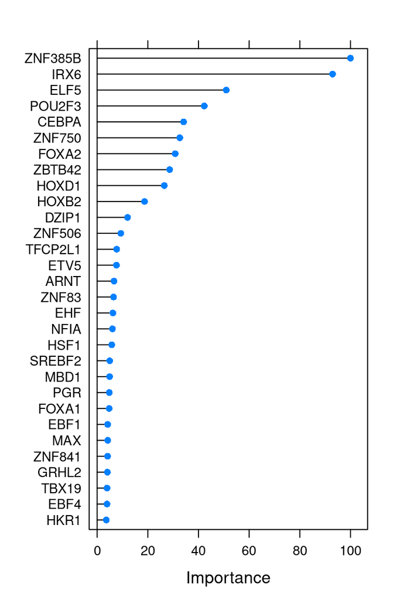

```r
# plot most important variables
plot(varImp(bagging_tree), 30)
```